# Introduction to CVXR!

## 4.3 Curvature

Each (sub)expression is flagged as one of the following curvatures (with respect to its variables) using the composition rules given in section 4.4:

| Curvature | Meaning |
| --- | --- |
| constant | $f(x)$ independent of $x$ |
| affine | $f( \theta x + (1-\theta)y) = \theta f(x) + (1 - \theta) f(y), \forall x, y, \theta \in [0, 1]$ |
| convex | $f( \theta x + (1-\theta)y) \leq \theta f(x) + (1 - \theta) f(y), \forall x, y, \theta \in [0, 1]$ |
| concave | $f( \theta x + (1-\theta)y) \geq \theta f(x) + (1 - \theta) f(y), \forall x, y, \theta \in [0, 1]$ |
| unknown | DCP analysis cannot determine the curvature |

As with sign analysis, the conclusion is always correct, but the simple analysis can flag expressions as unknown even when they are convex or concave. Note that any constant expression is also affine, and any affine expression is convex and concave.

## 4.4 General Composition Rule

DCP analysis is based on applying a general composition theorem from convex analysis to each (sub)expression.

$f(\text{expr}_1, \text{expr}_2,...,\text{expr}_n)$ is convex if $f$ is a convex function and for each $\text{expr}_i$ one of the following conditions holds:

- $f$ is increasing in argument $i$ and $\text{expr}_i$ is convex.
- $f$ is decreasing in argument $i$ and $\text{expr}_i$ is concave.
- $expr_i$ is affine or constant.

$f(\text{expr}_1, \text{expr}_2,...,\text{expr}_n)$ is concave if $f$ is a concave function and for each $\text{expr}_i$ one of the following conditions holds:

- $f$ is increasing in argument $i$ and $\text{expr}_i$ is concave.
- $f$ is decreasing in argument $i$ and $\text{expr}_i$ is convex.
- $\text{expr}_i$ is affine or constant.

$f(\text{expr}_1, \text{expr}_2,...,\text{expr}_n)$ is affine if $f$ is an affine function and each $\text{expr}_i$ is affine.

If none of the three rules apply, the expression $f(\text{expr}_1, \text{expr}_2,...,\text{expr}_n)$ is marked as having unknown curvature.

Whether a function is increasing or decreasing in an argument may depend on the sign of the argument. For instance, `square()` is increasing for positive arguments and decreasing for negative arguments.

The curvature of an expression is stored as `expr$curvature`:

```r
x = Variable()
a = Parameter(sign="positive")

paste0("curvature of x: ", x$curvature)
paste0("curvature of a: ", a$curvature)
paste0("curvature of square(x): ", square(x)$curvature)
paste0("curvature of sqrt(x): ", sqrt(x)$curvature)
```

[output not shown]

The infix operators `+, -, *, /` are treated exactly like functions. The infix operators `+` and `-` are affine, so the rules above are used to flag the curvature. For example, `expr1 + expr2` is flagged as convex if `expr1` and `expr2` are convex.

`expr1*expr2` is allowed only when one of the expressions is constant. If both expressions are non-constant, `CVXR` will raise an exception. `expr1/expr2` is allowed only when `expr2` is a scalar constant. The curvature rules above apply. For example, `expr1/expr2` is convex when `expr1` is concave and `expr2` is negative and constant. This is sometimes referred to as the No-Product Rule.

## 4.6 Example 1

DCP analysis breaks expressions down into subexpressions. The tree visualization below shows how this works for the expression `2*square(x) + 3`. Each subexpression is shown in a blue box. We mark its curvature on the left and its sign on the right.

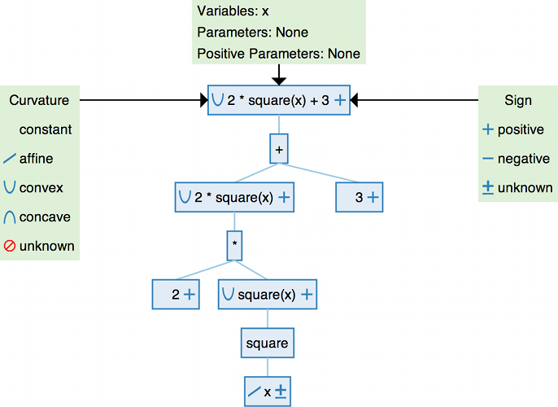

The variable `x` has affine curvature and unknown sign. The `square` function is convex and non-monotone for arguments of unknown sign. It can take the affine expression `x` as an argument; the result `square(x)` is convex.

`2` is positive and constant. The `*` operator is positive and convex given that one input is positive convex and the other is positive constant. `3` is positive and constant, and the arithmetic operator `+` is affine and increasing, so the composition `2*square(x) + 3` is convex by the curvature rule for convex functions and positive because both of its inputs are positive.

## 4.7 Example 2

We’ll walk through the application of the DCP rules to the expression `sqrt(1 + square(x))`.

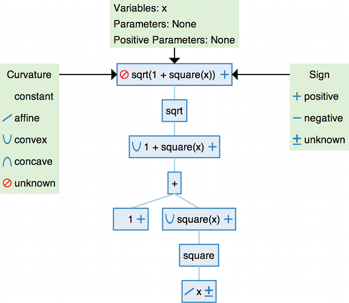

As in Example 1, `square(x)` is convex and positive.

The arithmetic operator `+` is affine and increasing, so the composition `1 + square(x)` is convex by the curvature rule for convex functions. The function `sqrt` is concave and increasing, which means it can only take a concave argument. Since `1 + square(x)` is convex, `sqrt(1 + square(x))` violates the DCP rules and cannot be verified as convex.

```r
paste0("sqrt(1 + square(x)) curvature: ", sqrt(1 + square(x))$curvature)
paste0("norm(vstack(1, x), 2) curvature: ", norm(c(1, x), 2)$curvature)
```

[output not shown]

## 4.9 Constraints

The list of supported convex constraints is

- *affine* `==` *affine*
- *convex* `<=` *concave*
- *concave* `>=` *convex*

Note that an affine expression is both convex and concave, so a constraint like

```r
Constraints( abs(x) <= y ) )
```

is valid because `y` is affine and thus also concave. Non-equality `!=` is not supported because they are almost never convex.

## 4.9 Problems

A problem is formed with an objective and a list of constraints.

# 5 The CVXR Function Library

This section describes the library of functions that can be applied to `CVXR` expressions. `CVXR` uses the function information in this section and the DCP rules to mark expressions with a sign and curvature.

## 5.1 Operators

The infix operators `+, -, *, /` are treated as functions. `+` and `-` are affine functions. `*` and `/` are affine in `CVXR` because `expr1*expr2` is allowed only when one of the expressions is constant and `expr1/expr2` is allowed only when `expr2` is a scalar constant.

## 5.2 Indexing and Slicing

All non-scalar expressions can be indexed using the syntax `expr[i, j]`. Indexing is an affine function. The syntax `expr[i]` can be used as a shorthand for `expr[i, 1]` when `expr` is a column vector. Similarly, `expr[i]` is shorthand for `expr[1, i]` when `expr` is a row vector.

Non-scalar expressions can also be sliced into using the standard `R` slicing syntax. For example, `expr[seq(i, j, k), r]` selects every `k`th element in column `r` of `expr`, starting at row `i` and ending at row `j`.

`CVXR` supports advanced indexing using lists of indices or boolean arrays. The semantics are the same as in base `R`.

## 5.3 Transpose

The transpose of any expression can be obtained using `t(expr)`. Transpose is an affine function.

## 5.4 Power

For any `CVXR` expression `expr`, the power operator `expr^p` is equivalent to the function `power(expr, p)`.

## 5.5 Scalar Functions

pos, neg, max, min, norm, square, sum_square, sqrt, log, exp, entr

A scalar function takes one or more scalars, vectors, or matrices as arguments and returns a scalar.

| Function | Meaning | Domain | Sign | Curvature |
| --- | --- | --- | --- | --- |
| geo_mean(x) geo_mean(x, p) $p \in R_+^n$ $p \neq 0$ | $x_1^{1/n} \cdots x_n^{1/n}$ $(x_1^{p_1} \cdots x_n^{p_n})^{\frac{1}{\mathbf{1}^T p}}$ | $x \in \mathbf{R}_+^n$ | positive | concave |
| harmonic_mean(x) | $\frac{n}{\frac{1}{x_1} + \cdots \frac{1}{x_n}}$ | $x \in \mathbf{R}_+^n$ | positive | concave |